# Telco_Churn_TidyModels

Sérgio Gomes

5/26/2020

## **Telco Churn Database**

```r
library(tidymodels)
library(tidyverse)
library(kknn)
library(sparklyr)
library(ggplot2)
```

### **Database**

The database that will be used for this analysis can be downloaded in [kaggle](https://www.kaggle.com/blastchar/telco-customer-churn/download/ZWMZ7eJn4JopEyd19XXH%2Fversions%2Fkr6hAklHVEdKMOUkTQOs%2Ffiles%2FWA_Fn-UseC_-Telco-Customer-Churn.csv?datasetVersionNumber=1).

### **Importing a database**

As a database could be large and it would make it difficult and time-consuming to be read. Because of it could be importante reading a small extraction of the data as text, to be able to analyze how the data is structured, check if there is or not a header, define the data separator, the decimal and thousant separators. Reading first 5 lines of the file.

```r
path <- "../Data"
file <- "/WA_Fn-UseC_-Telco-Customer-Churn.csv"
path_file <- paste(path, file, sep = "")
base_txt <- readLines(con = path_file, n = 5)
# checking the content of the extraction
base_txt
```

```
## [1] "customerID,gender,SeniorCitizen,Partner,Dependents,tenure,PhoneService,MultipleLines,InternetService,OnlineSecurity,OnlineBackup,DeviceProtection,TechSupport,StreamingTV,StreamingMovies,Contract,PaperlessBilling,PaymentMethod,MonthlyCharges,TotalCharges,Churn"
## [2] "7590-VHVEG,Female,0,Yes,No,1,No,No phone service,DSL,No,Yes,No,No,No,No,Month-to-month,Yes,Electronic check,29.85,29.85,No"
## [3] "5575-GNVDE,Male,0,No,No,34,Yes,No,DSL,Yes,No,Yes,No,No,No,One year,No,Mailed check,56.95,1889.5,No"
## [4] "3668-QPYBK,Male,0,No,No,2,Yes,No,DSL,Yes,Yes,No,No,No,No,Month-to-month,Yes,Mailed check,53.85,108.15,Yes"
## [5] "7795-CFOCW,Male,0,No,No,45,No,No phone service,DSL,Yes,No,Yes,Yes,No,No,One year,No,Bank transfer (automatic),42.3,1840.75,No"
```

Findings:

- Has header
- Data Separator: ‘,’
- Decimal Separator: ‘.’
- Thousand Separator: none

Based on the findings, the read function that better fits is `read.csv`, because it matches with the findings:

```r
base <- read.csv(path_file, header = TRUE)
```

Viewing a preview of the imported data

```r
head(base)
```

```
##   customerID gender SeniorCitizen Partner Dependents tenure PhoneService
## 1 7590-VHVEG Female             0     Yes         No      1           No
## 2 5575-GNVDE   Male             0      No         No     34          Yes
## 3 3668-QPYBK   Male             0      No         No      2          Yes
## 4 7795-CFOCW   Male             0      No         No     45           No
## 5 9237-HQITU Female             0      No         No      2          Yes
## 6 9305-CDSKC Female             0      No         No      8          Yes
##      MultipleLines InternetService OnlineSecurity OnlineBackup DeviceProtection
## 1 No phone service             DSL             No          Yes               No
## 2               No             DSL            Yes           No              Yes
## 3               No             DSL            Yes          Yes               No
## 4 No phone service             DSL            Yes           No              Yes
## 5               No     Fiber optic             No           No               No
## 6              Yes     Fiber optic             No           No              Yes
##   TechSupport StreamingTV StreamingMovies       Contract PaperlessBilling
## 1          No          No              No Month-to-month              Yes
## 2          No          No              No       One year               No
## 3          No          No              No Month-to-month              Yes
## 4         Yes          No              No       One year               No
## 5          No          No              No Month-to-month              Yes
## 6          No         Yes             Yes Month-to-month              Yes
##               PaymentMethod MonthlyCharges TotalCharges Churn
## 1          Electronic check          29.85        29.85    No
## 2              Mailed check          56.95      1889.50    No
## 3              Mailed check          53.85       108.15   Yes
## 4 Bank transfer (automatic)          42.30      1840.75    No
## 5          Electronic check          70.70       151.65   Yes
## 6          Electronic check          99.65       820.50   Yes
```

### **Analyzing the Imported data**

Checking field type and data examples

```r
glimpse(base)
```

```
## Observations: 7,043
## Variables: 21
## $ customerID       <fct> 7590-VHVEG, 5575-GNVDE, 3668-QPYBK, 7795-CFOCW, 92...
## $ gender           <fct> Female, Male, Male, Male, Female, Female, Male, Fe...
## $ SeniorCitizen    <int> 0, 0, 0, 0, 0, 0, 0, 0, 0, 0, 0, 0, 0, 0, 0, 0, 0,...
## $ Partner          <fct> Yes, No, No, No, No, No, No, No, Yes, No, Yes, No,...
## $ Dependents       <fct> No, No, No, No, No, No, Yes, No, No, Yes, Yes, No,...
## $ tenure           <int> 1, 34, 2, 45, 2, 8, 22, 10, 28, 62, 13, 16, 58, 49...
## $ PhoneService     <fct> No, Yes, Yes, No, Yes, Yes, Yes, No, Yes, Yes, Yes...
## $ MultipleLines    <fct> No phone service, No, No, No phone service, No, Ye...
## $ InternetService  <fct> DSL, DSL, DSL, DSL, Fiber optic, Fiber optic, Fibe...
## $ OnlineSecurity   <fct> No, Yes, Yes, Yes, No, No, No, Yes, No, Yes, Yes, ...
## $ OnlineBackup     <fct> Yes, No, Yes, No, No, No, Yes, No, No, Yes, No, No...
## $ DeviceProtection <fct> No, Yes, No, Yes, No, Yes, No, No, Yes, No, No, No...
## $ TechSupport      <fct> No, No, No, Yes, No, No, No, No, Yes, No, No, No i...
## $ StreamingTV      <fct> No, No, No, No, No, Yes, Yes, No, Yes, No, No, No ...
## $ StreamingMovies  <fct> No, No, No, No, No, Yes, No, No, Yes, No, No, No i...
## $ Contract         <fct> Month-to-month, One year, Month-to-month, One year...
## $ PaperlessBilling <fct> Yes, No, Yes, No, Yes, Yes, Yes, No, Yes, No, Yes,...
## $ PaymentMethod    <fct> Electronic check, Mailed check, Mailed check, Bank...
## $ MonthlyCharges   <dbl> 29.85, 56.95, 53.85, 42.30, 70.70, 99.65, 89.10, 2...
## $ TotalCharges     <dbl> 29.85, 1889.50, 108.15, 1840.75, 151.65, 820.50, 1...
## $ Churn            <fct> No, No, Yes, No, Yes, Yes, No, No, Yes, No, No, No...
```

Checking data summary. This summary helps to analyze the data content, where factor types are grouped and counted and numeric are summarized with Boxplot metrics.

```r
summary(base)
```

```
##       customerID      gender     SeniorCitizen    Partner    Dependents
##  0002-ORFBO:   1   Female:3488   Min.   :0.0000   No :3641   No :4933
##  0003-MKNFE:   1   Male  :3555   1st Qu.:0.0000   Yes:3402   Yes:2110
##  0004-TLHLJ:   1                 Median :0.0000
##  0011-IGKFF:   1                 Mean   :0.1621
##  0013-EXCHZ:   1                 3rd Qu.:0.0000
##  0013-MHZWF:   1                 Max.   :1.0000
##  (Other)   :7037
##      tenure      PhoneService          MultipleLines     InternetService
##  Min.   : 0.00   No : 682     No              :3390   DSL        :2421
##  1st Qu.: 9.00   Yes:6361     No phone service: 682   Fiber optic:3096
##  Median :29.00                Yes             :2971   No         :1526
##  Mean   :32.37
##  3rd Qu.:55.00
##  Max.   :72.00
##
##              OnlineSecurity              OnlineBackup
##  No                 :3498   No                 :3088
##  No internet service:1526   No internet service:1526
##  Yes                :2019   Yes                :2429
##
##
##
##
##             DeviceProtection              TechSupport
##  No                 :3095    No                 :3473
##  No internet service:1526    No internet service:1526
##  Yes                :2422    Yes                :2044
##
##
##
##
##               StreamingTV              StreamingMovies           Contract
##  No                 :2810   No                 :2785   Month-to-month:3875
##  No internet service:1526   No internet service:1526   One year      :1473
##  Yes                :2707   Yes                :2732   Two year      :1695
##
##
##
##
##  PaperlessBilling                   PaymentMethod  MonthlyCharges
##  No :2872         Bank transfer (automatic):1544   Min.   : 18.25
##  Yes:4171         Credit card (automatic)  :1522   1st Qu.: 35.50
##                   Electronic check         :2365   Median : 70.35
##                   Mailed check             :1612   Mean   : 64.76
##                                                    3rd Qu.: 89.85
##                                                    Max.   :118.75
##
##   TotalCharges    Churn
##  Min.   :  18.8   No :5174
##  1st Qu.: 401.4   Yes:1869
##  Median :1397.5
##  Mean   :2283.3
##  3rd Qu.:3794.7
##  Max.   :8684.8
##  NA's   :11
```

Based on the analysis, as usual we can remove the field ‘*customerID*’, as this data is unique for each row. All other columns will be used. Also, there is a field where there are 11 NAs in column ‘*TotalCharges*’, that must be treated later. The outcome is ‘*Churn*’ column.

```r
base <- base %>% select(-customerID)
```

### **Using TidyModels to Prepare the Database**

Separating database in 2 fractions for training (75%) and testing (25%) As our analysis will be for ‘*Classification*’. it is important to use the `strata=` option. This option keeps the propotionality of the selected outcome (‘*Churn*’ column).

```r
# It is recommended to use set.seed to fix a seed, in order to be able to find the same result for future runings and be able to perform a fair comparison between models and between analysis from others.
set.seed(123)
base_prop <- initial_split(base, prop = 0.75, strata = "Churn")
tr <- base_prop %>% training()
teste <- base_prop %>% testing()
```

#### `Recipe` Step

The `recipe` is a database preparation that pretends to “fix” data imperfections, like: * Missed values

- How:
  - Excluding `NA`
  - Filling missed data by median or mean
- Unstandarized Data:
  - How:
    - Normalizing the data, to have all numeric in a similar base

Writing the `recipe` to prepare the data.

```r
reci <- tr %>% recipe(Churn ~ .) %>%
  step_normalize(all_numeric()) %>%
  step_dummy(all_nominal(), -all_outcomes()) %>%
  step_medianimpute(TotalCharges)
```

Includes the ingredients into the `recipe`. This `recipe` is baked using the ‘*training*’ data, as stated in the `recipe` variable.

```r
base_prep <- prep(reci)
```

As the `recipe` has already been prepared using the ‘*training*’ data, is it possible to use `juice` just to bring the baked data from training data. No need to `bake` it.

```r
baked_tr <- juice(base_prep)
```

Baking the `recipe`, now using the ‘*test*’ data instead of ‘*training*’

```r
baked_teste <- bake(base_prep, new_data = teste)
```

### **TidyModels Modeling - `parsnip`**

In this section, will be presented the modeling for classification of Telco_Churn, using many different models.

It is important to see that using *TidyModels* for it, the code for the models are similar and easy to understand all, once one is understood. *Tidymodels* makes the use of many models standarized, turning a confusing task in a simpler and more organized one.

We will run the classification using the following models:

- Random Forest;
- Lasso;
- SVM_Polynomial;
- SVM_Linear;
- SVM_Radial;
- KNN;
- XGBoosting.

After all predicting, an ROC_AUC performance comparison is done to determine the model that achieved the better performance.

Additional to the performance comparison, a timing comparison will be done to compare the time consume for each model. For this timing analysis, the system time will be collected in two moments for each model: before and after model runing. The variables for that will be `start_time` and `end_time` and the time is the difference between them.

#### *Random Forest - Ranger*

Creating the model, but not defining the hyper-parameters arguments. Instead, they will be tunned to define the better value, using Cross-Validation (CV) testing. To do that, instead of setting a numeric value, the parameters will receive `tune()`. Also the model receive 2 other definitions: * Engine: `ranger` - because it have a better timing performance than `rpart` * Mode: `classification`

```r
start_time <- Sys.time()

floresta <- rand_forest(trees = tune(),
                          mtry = tune(),
                          min_n = tune()) %>%
                        set_engine("ranger") %>%
                        set_mode("classification")
```

Searching for better Hyerparameters, using Cross validation with 10 folds.

```r
cv_split <- vfold_cv(tr, v = 10, strata = "Churn")

doParallel::registerDoParallel()

floresta_hiper <- tune_grid(floresta,
                            reci,
                            resamples = cv_split,
                            grid = 10)
```

```
## i Creating pre-processing data to finalize unknown parameter: mtry
```

Getting the best parameters based on best ROC_AUC criteria.

```r
tuned_hiper <- floresta_hiper %>% select_best("roc_auc")
```

Finalizing the model with the defined parameters.

```r
floresta <- finalize_model(floresta, tuned_hiper)

fitted_floresta <- fit(floresta, Churn ~. ,data = baked_tr)

pred_floresta <- fitted_floresta %>% predict(new_data = baked_teste, type = "prob")


resultado <- tibble(Predito = pred_floresta$.pred_Yes,
                    Observado = baked_teste$Churn,
                    Modelo = "Floresta")

end_time <- Sys.time()



resultado_tempo <- tibble(Tempo = end_time - start_time,
                          Modelo = "Floresta")
```

#### *LASSO*

Similar to what has already been done for *Random Forest*, the same steps have being done for *LASSO*.

```r
# Modelo Lasso --------------------------------------------------------------
start_time <- Sys.time()
logistica <- logistic_reg(penalty = tune(), mixture = 1) %>%
  set_engine("glmnet") %>%
  set_mode("classification")

doParallel::registerDoParallel()

tuned_penalty <- tune_grid(logistica,
                           reci,
                           resamples = cv_split,
                           metrics = metric_set(roc_auc, accuracy),
                           grid = 10)

best_penalty <- tuned_penalty %>% select_best("roc_auc")

logistica <- finalize_model(logistica,
                            best_penalty)

fitted_glm <- fit(logistica,
                  data = baked_tr,
                  Churn ~ .)

pred_glm <- predict(fitted_glm, new_data = baked_teste, type = "prob")

resultado <- resultado %>% bind_rows(tibble(Predito = pred_glm$.pred_Yes,
                                            Observado = baked_teste$Churn,
                                            Modelo = "Lasso"))

end_time <- Sys.time()

resultado_tempo <- resultado_tempo %>% bind_rows(tibble(Tempo = end_time - start_time,
                                                        Modelo = "Lasso"))
```

#### *Modelo Knn*

```r
start_time <- Sys.time()
vizinhos <- nearest_neighbor(neighbors = tune()) %>%
  set_engine("kknn") %>%
  set_mode("classification")

doParallel::registerDoParallel()

tuned_vizinho <- tune_grid(vizinhos,
                           reci,
                           resamples = cv_split,
                           metrics = metric_set(roc_auc, accuracy),
                           grid = 10)

best_vizinhos <- tuned_vizinho %>% select_best("roc_auc")

vizinhos <- finalize_model(vizinhos, best_vizinhos)

fitted_knn <- fit(vizinhos,
                  data = baked_tr,
                  Churn ~ .)

pred_knn <- predict(fitted_knn, new_data = baked_teste, type = "prob")


resultado <- resultado %>% bind_rows(tibble(Predito = pred_knn$.pred_Yes,
                                            Observado = baked_teste$Churn,
                                            Modelo = "knn"))

end_time <- Sys.time()

resultado_tempo <- resultado_tempo %>% bind_rows(tibble(Tempo = end_time - start_time,
                                                        Modelo = "knn"))
```

#### *Modelo SVM_Poly*

```r
start_time <- Sys.time()
modelo_svm_poly <- svm_poly(
                        cost = tune(),
                        degree = tune(),
                        scale_factor = tune()
                        ) %>%
                        set_engine("kernlab") %>%
                        set_mode("classification")
```

```r
doParallel::registerDoParallel()

tuned_svm_poly <- tune_grid(modelo_svm_poly,
                            reci,
                            resamples = cv_split,
                            metrics = metric_set(roc_auc, accuracy),
                            grid = 10)

best_svm_poly <- tuned_svm_poly %>% select_best("roc_auc")
```

```r
modelo_svm_poly <- finalize_model(modelo_svm_poly,best_svm_poly)

fitted_svm_poly <- fit(modelo_svm_poly,
                       Churn ~ .,
                       data = baked_tr)

predicted_svm_poly <- predict(fitted_svm_poly, new_data = baked_teste, type = "prob")

resultado <- resultado %>% bind_rows(tibble(Predito = predicted_svm_poly$.pred_Yes,
                                            Observado = baked_teste$Churn,
                                            Modelo = "SVM_Poly"))

end_time <- Sys.time()

resultado_tempo <- resultado_tempo %>% bind_rows(tibble(Tempo = end_time - start_time,
                                                        Modelo = "SVM_Poly"))
```

#### *Modelo SVM_Radial*

```r
start_time <- Sys.time()
modelo_svm_radial <- svm_rbf(
                              cost = tune(),
                              rbf_sigma = tune()
                            ) %>%
                            set_engine("kernlab") %>%
                            set_mode("classification")
```

```r
doParallel::registerDoParallel()

tuned_svm_radial <- tune_grid(modelo_svm_radial,
                              reci,
                              resamples = cv_split,
                              metrics = metric_set(roc_auc, accuracy),
                              grid = 10)

best_svm_radial <- tuned_svm_radial %>% select_best("roc_auc")
```

```r
modelo_svm_radial <- finalize_model(modelo_svm_radial,best_svm_radial)

fitted_svm_radial <- fit(modelo_svm_radial,
                         Churn ~ .,
                         data = baked_tr)

predicted_svm_radial <- predict(fitted_svm_radial, new_data = baked_teste, type = "prob")

resultado <- resultado %>% bind_rows(tibble(Predito = predicted_svm_radial$.pred_Yes,
                                            Observado = baked_teste$Churn,
                                            Modelo = "SVM_Radial"))

end_time <- Sys.time()

resultado_tempo <- resultado_tempo %>% bind_rows(tibble(Tempo = end_time - start_time,
                                                        Modelo = "SVM_Radial"))
```

#### *Modelo SVM_Poly_Vanilla*

```r
start_time <- Sys.time()
modelo_svm_poly_van <- svm_poly(
                                cost = tune(),
                                degree = tune(),
                                scale_factor = tune()
                                ) %>%
  set_args(kernel = "vanilladot") %>%
  set_engine("kernlab") %>%
  set_mode("classification")
```

```r
doParallel::registerDoParallel()

tuned_svm_poly_van <- tune_grid(modelo_svm_poly_van,
                            reci,
                            resamples = cv_split,
                            metrics = metric_set(roc_auc, accuracy),
                            grid = 10)

best_svm_poly_van <- tuned_svm_poly_van %>% select_best("roc_auc")
```

```r
modelo_svm_poly_van <- finalize_model(modelo_svm_poly_van,best_svm_poly_van)

fitted_svm_poly_van <- fit(modelo_svm_poly_van,
                       Churn ~ .,
                       data = baked_tr)

predicted_svm_poly_van <- predict(fitted_svm_poly_van, new_data = baked_teste, type = "prob")

resultado <- resultado %>% bind_rows(tibble(Predito = predicted_svm_poly_van$.pred_Yes,
                                            Observado = baked_teste$Churn,
                                            Modelo = "SVM_Poly_Vanilla"))

end_time <- Sys.time()

resultado_tempo <- resultado_tempo %>% bind_rows(tibble(Tempo = end_time - start_time,
                                                        Modelo = "SVM_Poly_Vanilla"))
```

#### *XGboosting*

```r
start_time <- Sys.time()
modelo_boosting <- boost_tree(
                                tree_depth = tune(),
                                trees = tune(),
                                learn_rate = tune(),
                                mtry = tune(),
                                min_n = tune(),
                                loss_reduction = tune()
                              ) %>%
  set_engine("xgboost") %>%
  set_mode("classification")
```

```r
doParallel::registerDoParallel()

tuned_boosting <- tune_grid(modelo_boosting,
                            reci,
                            resamples = cv_split,
                            metrics = metric_set(roc_auc, accuracy),
                            grid = 10)
```

```
## i Creating pre-processing data to finalize unknown parameter: mtry
```

```r
best_tuned_boosting <- tuned_boosting %>% select_best("roc_auc")
```

```r
modelo_boosting <- finalize_model(modelo_boosting,best_tuned_boosting)

fitted_boosting <- fit(modelo_boosting,
                       Churn ~ .,
                       data = baked_tr)

predicted_boosting <- predict(fitted_boosting, new_data = baked_teste, type = "prob")

resultado <- resultado %>% bind_rows(tibble(Predito = predicted_boosting$.pred_Yes,
                                            Observado = baked_teste$Churn,
                                            Modelo = "Boosting"))

end_time <- Sys.time()

resultado_tempo <- resultado_tempo %>% bind_rows(tibble(Tempo = end_time - start_time,
                                                        Modelo = "Boosting"))
```

#### **Graphic Comparison - `yardstick`**

##### **ROC_AUC**

After running all models, the graphics below present the comparison between these models.

Comparing the performance based on ROC_AUC.

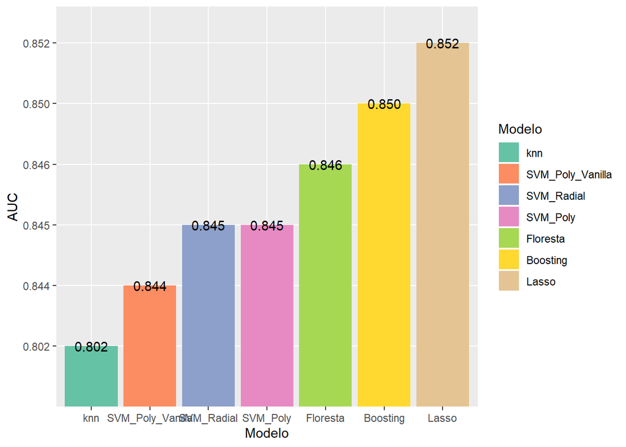

```r
resultado %>%
  group_by(Modelo) %>%
  roc_auc(Observado, Predito) %>%
  mutate(Modelo = fct_reorder(Modelo,.estimate),
         .estimate = format(.estimate, digits=3)) %>%
  ggplot(aes(x = Modelo, y = .estimate))+
    geom_col(aes(fill = Modelo))+
    scale_fill_brewer(palette = "Set2")+
    geom_text(aes(label=.estimate),position=position_stack())+
    ylab("AUC")
```

Also presenting the ROC Curves for all models.

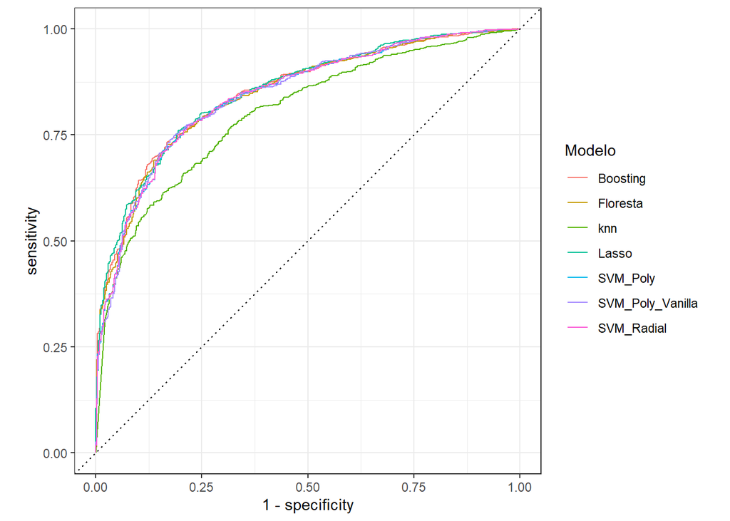

```r
resultado %>%
  group_by(Modelo) %>%
  roc_curve(Observado, Predito) %>%
  autoplot()
```

##### **Timing**

In the graphic below, it is presented the timing comparison.

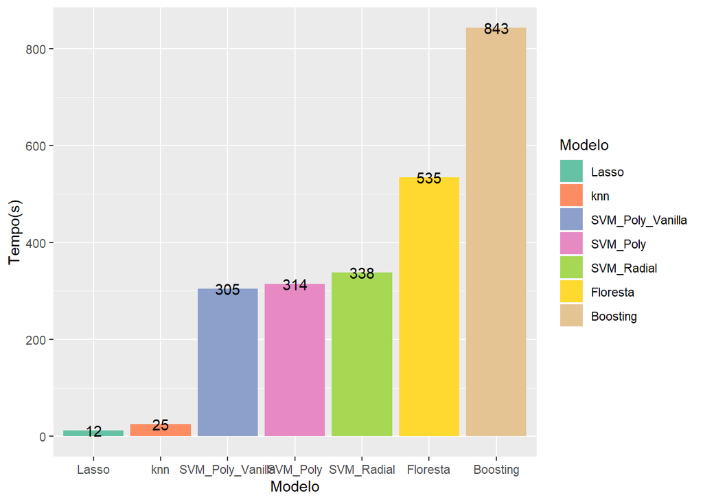

```r
resultado_tempo2 <- resultado_tempo %>% mutate(Tempo = as.integer(Tempo))

resultado_tempo2 %>%
  mutate(Modelo = fct_reorder(Modelo, Tempo)) %>%
  ggplot(aes(x = Modelo, y = Tempo))+
    geom_col(aes(fill = Modelo))+
    scale_fill_brewer(palette = "Set2")+
    geom_text(aes(label=Tempo),position=position_stack())+
    ylab("Tempo(s)")
```

### **Conclusion**

It is possible to see the faster models were the simplers (*KNN* and *Lasso*), however in the perfomance, *KNN* lose by far to *LASSO* that had the best performance.